# Выполнение ЛР №4: Иерархическая и вероятностная кластеризации

## Задание 2 (Датасет #1)

### Формулировка

Для первого датасета:

- Определить число кластеров, построив дендрограмму.

### Решение

#### Построение дендрограмм с разными методами связывания

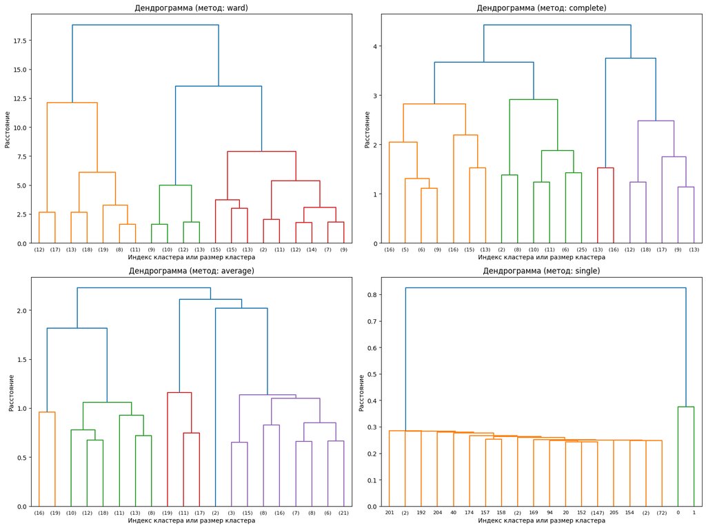

```python
flame_features_norm = flame_data_norm[["x_norm", "y_norm"]]
methods = ['ward', 'complete', 'average', 'single']
metrics = ['euclidean', 'manhattan', 'chebyshev', 'hamming']
fig, axes = plt.subplots(2, 2, figsize=(16, 12))
axes = axes.ravel()

linkage_matrices = {}

for i, method in enumerate(methods):
    # Вычисление матрицы связей
    linkage_matrix = linkage(flame_features_norm, method=method, metric=metrics[0])

    linkage_matrices[method] = linkage_matrix

    # Построение дендрограммы
    dendrogram(linkage_matrix, ax=axes[i], truncate_mode='lastp', p=20, leaf_font_size=8)
    axes[i].set_title(f'Дендрограмма (метод: {method})')
    axes[i].set_xlabel('Индекс кластера или размер кластера')
    axes[i].set_ylabel('Расстояние')

plt.tight_layout()
plt.show()
```

#### Детальная дендрограмма для метода Ward (наиболее подходящий для данной задачи)

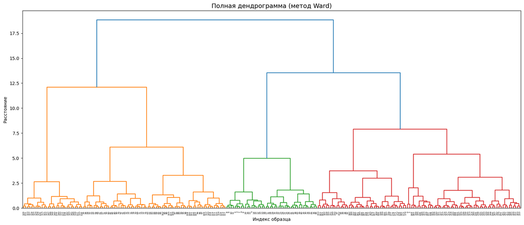

```python
plt.figure(figsize=(20, 8))

# Построение полной дендрограммы
ward_linkage = linkage_matrices['ward']
dendrogram(ward_linkage, leaf_rotation=90, leaf_font_size=5)
plt.title('Полная дендрограмма (метод Ward)', fontsize=14)
plt.xlabel('Индекс образца')
plt.ylabel('Расстояние')

plt.show()
```

#### Добавляет линии порогов для 2х и 3х кластеров

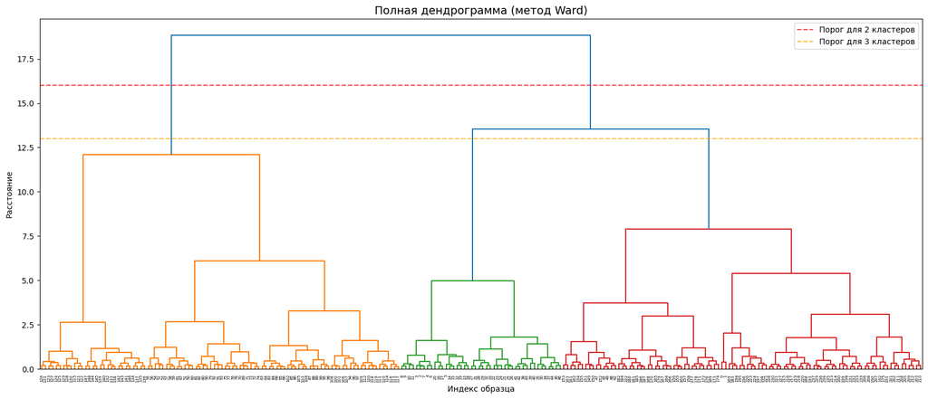

```python
ward_linkage = linkage_matrices['ward']
plt.figure(figsize=(20, 8))
dendrogram(ward_linkage, leaf_rotation=90, leaf_font_size=5)
plt.title('Полная дендрограмма (метод Ward)', fontsize=14)
plt.xlabel('Индекс образца')
plt.ylabel('Расстояние')
plt.axhline(y=16, color='red', linestyle='--', alpha=0.7, label='Порог для 2 кластеров')
plt.axhline(y=13, color='orange', linestyle='--', alpha=0.7, label='Порог для 3 кластеров')

plt.legend()
plt.show()
```

#### Выводы

1. АНАЛИЗ ДЕНДРОГРАММЫ:
   - Наибольшие скачки на последних этапах слияния можно наблюдать в методах `Complete` и `Ward`
   - Метод `Ward` показал наилучшие результаты для данного датасета
   - Дендрограмма показывает два или три основных кластера

## Задание 3 (Датасет #1)

### Формулировка

Для первого датасета:

- Построить график зависимости расстояний между кластерами от шага слияния.
- Определить по графику оптимальное число кластеров.

### Решение

```python
# Извлекаем расстояния слияния из матрицы связей
ward_linkage = linkage_matrices['ward']
distances = ward_linkage[:, 2]
```

#### График зависимости расстояний от шага слияния

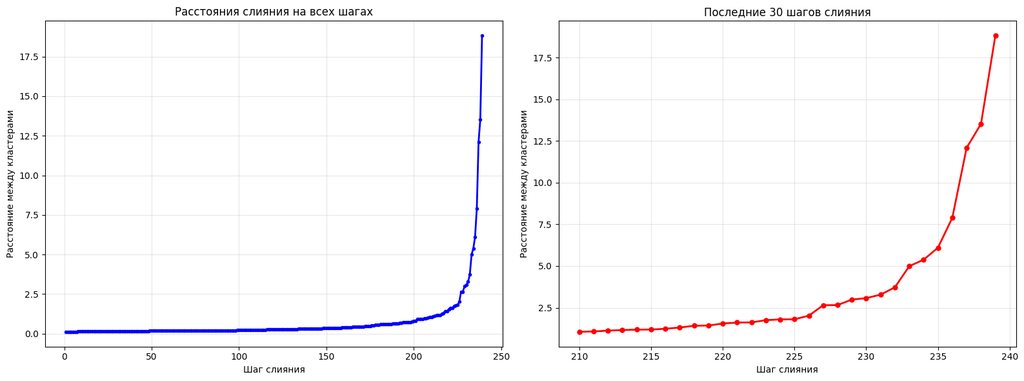

```python
# Создаем массив шагов слияния (от 1 до n-1, где n - количество точек)
steps = np.arange(1, len(distances) + 1)

fig, axes = plt.subplots(1, 2, figsize=(16, 6))

# График 1: Полный график всех шагов слияния
axes[0].plot(steps, distances, 'b-', linewidth=2, marker='o', markersize=3)
axes[0].set_title('Расстояния слияния на всех шагах', fontsize=12)
axes[0].set_xlabel('Шаг слияния')
axes[0].set_ylabel('Расстояние между кластерами')
axes[0].grid(True, alpha=0.3)

# График 2: Последние 30 шагов (наиболее важные для определения числа кластеров)
last_steps = 30
axes[1].plot(steps[-last_steps:], distances[-last_steps:], 'r-', linewidth=2, marker='o', markersize=5)
axes[1].set_title(f'Последние {last_steps} шагов слияния', fontsize=12)
axes[1].set_xlabel('Шаг слияния')
axes[1].set_ylabel('Расстояние между кластерами')
axes[1].grid(True, alpha=0.3)

plt.tight_layout()
plt.show()
```

#### Графики приращений расстояний

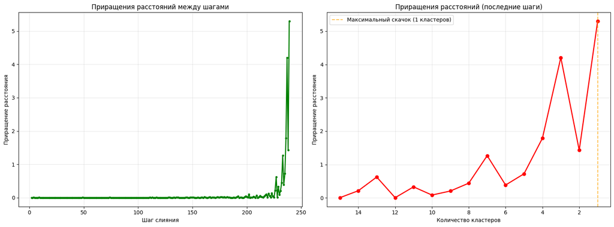

```python
# Вычисляем разницу между последовательными расстояниями
distance_diffs = np.diff(distances)

# График приращений
fig, axes = plt.subplots(1, 2, figsize=(16, 6))

# График 1: Все приращения
axes[0].plot(range(2, len(distances) + 1), distance_diffs, 'g-', linewidth=2, marker='o', markersize=3)
axes[0].set_title('Приращения расстояний между шагами', fontsize=12)
axes[0].set_xlabel('Шаг слияния')
axes[0].set_ylabel('Приращение расстояния')
axes[0].grid(True, alpha=0.3)

# График 2: Последние приращения (в обратном порядке - от большего к меньшему числу кластеров)
last_steps_diff = 15
x_clusters = np.arange(last_steps_diff, 0, -1)
y_diffs = distance_diffs[-last_steps_diff:]

axes[1].plot(x_clusters, y_diffs, 'r-', linewidth=2, marker='o', markersize=6)
axes[1].set_title('Приращения расстояний (последние шаги)', fontsize=12)
axes[1].set_xlabel('Количество кластеров')
axes[1].set_ylabel('Приращение расстояния')
axes[1].grid(True, alpha=0.3)
axes[1].invert_xaxis()  # Инвертируем ось X для удобства чтения

# Выделяем наибольшие скачки
max_diff_idx = np.argmax(distance_diffs[-last_steps_diff:])
axes[1].axvline(x=x_clusters[max_diff_idx], color='orange', linestyle='--',
                alpha=0.7, label=f'Максимальный скачок ({x_clusters[max_diff_idx]} кластеров)')
axes[1].legend()

plt.tight_layout()
plt.show()
```

#### Определение оптимального числа кластеров методом "локтя"

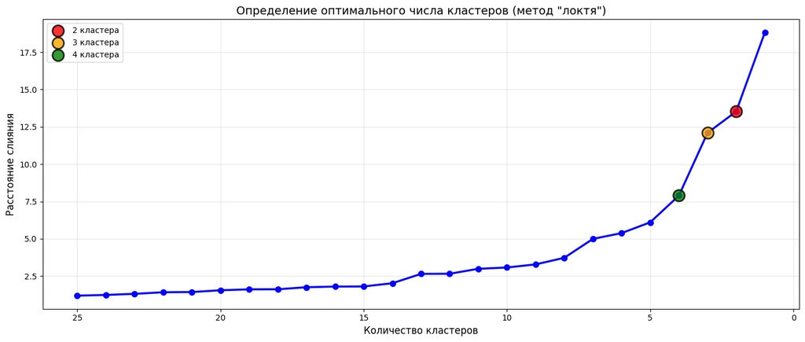

```python
# Визуализация оптимального числа кластеров
plt.figure(figsize=(14, 6))

# Строим график в обратном порядке (от многих кластеров к малому числу)
n_points = 25
clusters_range = np.arange(n_points, 0, -1)
distances_subset = distances[-n_points:]

plt.plot(clusters_range, distances_subset, 'b-', linewidth=2.5, marker='o', markersize=7)
plt.title('Определение оптимального числа кластеров (метод "локтя")', fontsize=14)
plt.xlabel('Количество кластеров', fontsize=12)
plt.ylabel('Расстояние слияния', fontsize=12)
plt.grid(True, alpha=0.3)

# Отмечаем потенциальные оптимальные точки
optimal_candidates = [2, 3, 4]
colors = ['red', 'orange', 'green']
for k, color in zip(optimal_candidates, colors):
    idx = n_points - k
    plt.scatter(k, distances_subset[idx], s=200, c=color, alpha=0.8,
                edgecolors='black', linewidth=2, zorder=5,
                label=f'{k} кластера')

plt.gca().invert_xaxis()
plt.legend()
plt.tight_layout()
plt.show()
```

### Вывод

**Анализ графиков:**

1. **График расстояний слияния** показывает, что наибольшие скачки происходят на последних этапах слияния, когда количество кластеров уменьшается с 4 до 3 и с 2 до 1.
2. **График приращений расстояний** четко демонстрирует "локти" - точки, где приращение резко возрастает:
   - Самый большой скачок наблюдается при переходе от 2 к 1 кластеру
   - Второй значительный скачок - при переходе от 4 к 3 кластерам
3. **Оптимальное число кластеров:**
   - **4 кластера** - наиболее очевидный выбор, так как это на следующем этапе слияния наблюдается первый существенный скачок.
   - **2 кластера** - также хороший вариант, учитывая что он по величине приращения является наибольшим. Стоит учитывать, что слияние от 3 кластеров к 2 не дало значительного приращения расстояния, что свидетельствует о формировании неестественной группы.
4. **Рекомендация:** Для датасета flame, на основе графика зависимости расстояния между кластерами от шага слияния, оптимальным является **4 кластера**. Окончательный выбор будет сделан в следующем задании.

## Задание 4 (Датасет #1)

### Формулировка

Для первого датасета:

- Выбрать оптимальный алгоритм и выполнить кластеризацию.
- Пробовать разные варианты, чтобы определить наиболее подходящий вариант.

### Решение

#### Определение алгоритмов и параметров для тестирования

```python
# Используем нормализованные данные из задания 1
X_flame = flame_data_norm[['x_norm', 'y_norm']].values
true_labels = flame_data['cluster'].values

# Параметры для тестирования
n_clusters_list = [2 ,4]
algorithms = {
    'K-Means': None,
    'Agglomerative_Ward': 'ward',
    'Agglomerative_Single': 'single',
    'Agglomerative_Complete': 'complete',
    'Agglomerative_Average': 'average'
}
metrics = ['euclidean', 'manhattan', 'chebyshev', 'hamming']
```

```python
# Функция для вычисления внутренних метрик качества
def calculate_internal_metrics(X, labels):
    """Вычисляет компактность и отделимость кластеров"""
    unique_labels = np.unique(labels)
    n_clusters = len(unique_labels)

    if n_clusters < 2:
        return 0, 0

    # Компактность (внутрикластерная дисперсия)
    within_cluster_ss = 0
    cluster_centers = []

    for label in unique_labels:
        cluster_points = X[labels == label]
        if len(cluster_points) > 0:
            center = np.mean(cluster_points, axis=0)
            cluster_centers.append(center)
            within_cluster_ss += np.sum((cluster_points - center) ** 2)

    # Отделимость (межкластерная дисперсия)
    overall_center = np.mean(X, axis=0)
    between_cluster_ss = 0

    for i, label in enumerate(unique_labels):
        cluster_size = np.sum(labels == label)
        if cluster_size > 0:
            between_cluster_ss += cluster_size * np.sum((cluster_centers[i] - overall_center) ** 2)

    return within_cluster_ss, between_cluster_ss


def get_alg_result(alg_name, n_clusters, X_flame, true_labels, cluster_labels, other):
    # Вычисление метрик качества
    rand_score = adjusted_rand_score(true_labels, cluster_labels)
    #silhouette = silhouette_score(X_flame, cluster_labels)
    within_ss, between_ss = calculate_internal_metrics(X_flame, cluster_labels)
    sum_ss = between_ss - within_ss

     # Сохранение результатов
    result = {
        'algorithm': alg_name,
        'n_clusters': n_clusters,
        'rand_score': rand_score,
        #'silhouette_score': silhouette,
        'within_cluster_ss': within_ss,
        'between_cluster_ss': between_ss,
        'summ_cluster_ss': sum_ss,
        'labels': cluster_labels,
        'other': other
    }
    return result
```

#### Выполнение кластеризации всеми алгоритмами

```python
results = []

for n_clusters in n_clusters_list:
    for alg_name, linkage_method in algorithms.items():
        # Выполнение кластеризации
        if alg_name == 'K-Means':
            clusterer = KMeans(n_clusters=n_clusters, random_state=42, n_init=10)
            cluster_labels = clusterer.fit_predict(X_flame)
            results.append(get_alg_result(alg_name, n_clusters, X_flame, true_labels, cluster_labels,'lloyd'))
        else:
            # Агломеративная кластеризация
            if linkage_method == 'ward':
                _metrics = ['euclidean']
            else:
                _metrics = metrics
            for metric in _metrics:
                clusterer = AgglomerativeClustering(n_clusters=n_clusters, linkage=linkage_method, metric=metric)
                cluster_labels = clusterer.fit_predict(X_flame)
                results.append(get_alg_result(alg_name, n_clusters, X_flame, true_labels, cluster_labels,metric))
```

#### Анализ результатов и выбор лучших алгоритмов

```python
# Создание DataFrame с результатами
results_df = pd.DataFrame([{
    'Алгоритм': r['algorithm'],
    'Параметр': r['other'],
    'Кластеры': r['n_clusters'],
    'Индекс Рэнда': r['rand_score'],
    #'Силуэт': r['silhouette_score'],
    'Внутр. SS': r['within_cluster_ss'],
    'Межкл. SS': r['between_cluster_ss'],
    'Cумм. SS': r['summ_cluster_ss']
} for r in results])

print("\n" + "=" * 80)
print("СВОДНАЯ ТАБЛИЦА РЕЗУЛЬТАТОВ:")
print("=" * 80)
display(results_df.round(3))


# Выбор топ-3 алгоритмов по индексу Рэнда
print("\n" + "=" * 80)
print("Топ-3 алгоритмов по индексу Рэнда:")
print("=" * 80)

top_algorithms_rand = results_df.nlargest(3, 'Индекс Рэнда')
for idx, row in top_algorithms_rand.iterrows():
    print(f"{row['Алгоритм']} ({row['Кластеры']} кластеров): {row['Индекс Рэнда']:.3f}")


# # Выбор топ-3 алгоритмов по силуэту
# print("\n" + "=" * 80)
# print("Топ-3 алгоритмов по силуэту:")
# print("=" * 80)

# top_algorithms_silhouette = results_df.nlargest(3, 'Силуэт')
# for idx, row in top_algorithms_silhouette.iterrows():
#     print(f"{row['Алгоритм']} ({row['Кластеры']} кластеров): {row['Силуэт']:.3f}")


# Выбор топ-3 алгоритмов по дисперсии
print("\n" + "=" * 80)
print("Топ-3 алгоритмов по дисперсии:")
print("=" * 80)

top_algorithms_ss = results_df.nlargest(3, 'Cумм. SS')
for idx, row in top_algorithms_ss.iterrows():
    print(f"{row['Алгоритм']} ({row['Кластеры']} кластеров): {row['Cумм. SS']:.3f}")

# Выбор лучших алгоритмов по каждой метрике
print("\n" + "=" * 80)
print("Лучшие алгоритмы по каждой метрике:")
print("=" * 80)

best_rand = results_df.loc[results_df['Индекс Рэнда'].idxmax()]
#best_silhouette = results_df.loc[results_df['Силуэт'].idxmax()]
best_ss = results_df.loc[results_df['Cумм. SS'].idxmax()]

print(f"По индексу Рэнда: {best_rand['Алгоритм']} ({best_rand['Кластеры']} кластеров) = {best_rand['Индекс Рэнда']:.3f}")
#print(f"По силуэту: {best_silhouette['Алгоритм']} ({best_silhouette['Кластеры']} кластеров) = {best_silhouette['Силуэт']:.3f}")
print(f"По кластерной дисперсии: {best_ss['Алгоритм']} ({best_ss['Кластеры']} кластеров) = {best_ss['Cумм. SS']:.3f}")
```

```
================================================================================
СВОДНАЯ ТАБЛИЦА РЕЗУЛЬТАТОВ:
================================================================================
```

|  | Алгоритм | Параметр | Кластеры | Индекс Рэнда | Внутр. SS | Межкл. SS | Cумм. SS |
| --- | --- | --- | --- | --- | --- | --- | --- |
| 0 | K-Means | lloyd | 2 | 0.409 | 292.353 | 187.647 | -104.705 |
| 1 | Agglomerative_Ward | euclidean | 2 | 0.289 | 302.892 | 177.108 | -125.784 |
| 2 | Agglomerative_Single | euclidean | 2 | 0.013 | 466.517 | 13.483 | -453.033 |
| 3 | Agglomerative_Single | manhattan | 2 | 0.013 | 466.517 | 13.483 | -453.033 |
| 4 | Agglomerative_Single | chebyshev | 2 | 0.013 | 466.517 | 13.483 | -453.033 |
| 5 | Agglomerative_Single | hamming | 2 | 0.006 | 476.573 | 3.427 | -473.145 |
| 6 | Agglomerative_Complete | euclidean | 2 | 0.289 | 302.892 | 177.108 | -125.784 |
| 7 | Agglomerative_Complete | manhattan | 2 | 0.638 | 304.955 | 175.045 | -129.909 |
| 8 | Agglomerative_Complete | chebyshev | 2 | 0.431 | 299.566 | 180.434 | -119.133 |
| 9 | Agglomerative_Complete | hamming | 2 | 0.019 | 475.027 | 4.973 | -470.053 |
| 10 | Agglomerative_Average | euclidean | 2 | 0.357 | 301.493 | 178.507 | -122.986 |
| 11 | Agglomerative_Average | manhattan | 2 | -0.034 | 367.388 | 112.612 | -254.777 |
| 12 | Agglomerative_Average | chebyshev | 2 | 0.013 | 466.517 | 13.483 | -453.033 |
| 13 | Agglomerative_Average | hamming | 2 | 0.078 | 473.000 | 7.000 | -466.000 |
| 14 | K-Means | lloyd | 4 | 0.426 | 112.464 | 367.536 | 255.072 |
| 15 | Agglomerative_Ward | euclidean | 4 | 0.402 | 138.250 | 341.750 | 203.500 |
| 16 | Agglomerative_Single | euclidean | 4 | 0.019 | 462.660 | 17.340 | -445.320 |
| 17 | Agglomerative_Single | manhattan | 4 | 0.019 | 463.487 | 16.513 | -446.974 |
| 18 | Agglomerative_Single | chebyshev | 4 | 0.019 | 465.970 | 14.030 | -451.939 |
| 19 | Agglomerative_Single | hamming | 4 | 0.026 | 469.903 | 10.097 | -459.806 |
| 20 | Agglomerative_Complete | euclidean | 4 | 0.303 | 139.354 | 340.646 | 201.292 |
| 21 | Agglomerative_Complete | manhattan | 4 | 0.486 | 137.456 | 342.544 | 205.088 |
| 22 | Agglomerative_Complete | chebyshev | 4 | 0.449 | 130.365 | 349.635 | 219.270 |
| 23 | Agglomerative_Complete | hamming | 4 | 0.032 | 469.329 | 10.671 | -458.658 |
| 24 | Agglomerative_Average | euclidean | 4 | 0.635 | 179.774 | 300.226 | 120.451 |
| 25 | Agglomerative_Average | manhattan | 4 | 0.515 | 140.162 | 339.838 | 199.677 |
| 26 | Agglomerative_Average | chebyshev | 4 | 0.585 | 188.493 | 291.507 | 103.013 |
| 27 | Agglomerative_Average | hamming | 4 | 0.092 | 467.137 | 12.863 | -454.274 |

```
================================================================================
Топ-3 алгоритмов по индексу Рэнда:
================================================================================
Agglomerative_Complete (2 кластеров): 0.638
Agglomerative_Average (4 кластеров): 0.635
Agglomerative_Average (4 кластеров): 0.585

================================================================================
Топ-3 алгоритмов по дисперсии:
================================================================================
K-Means (4 кластеров): 255.072
Agglomerative_Complete (4 кластеров): 219.270
Agglomerative_Complete (4 кластеров): 205.088

================================================================================
Лучшие алгоритмы по каждой метрике:
================================================================================
По индексу Рэнда: Agglomerative_Complete (2 кластеров) = 0.638
По кластерной дисперсии: K-Means (4 кластеров) = 255.072
```

#### Визуализация результатов лучших алгоритмов по внешним метрикам

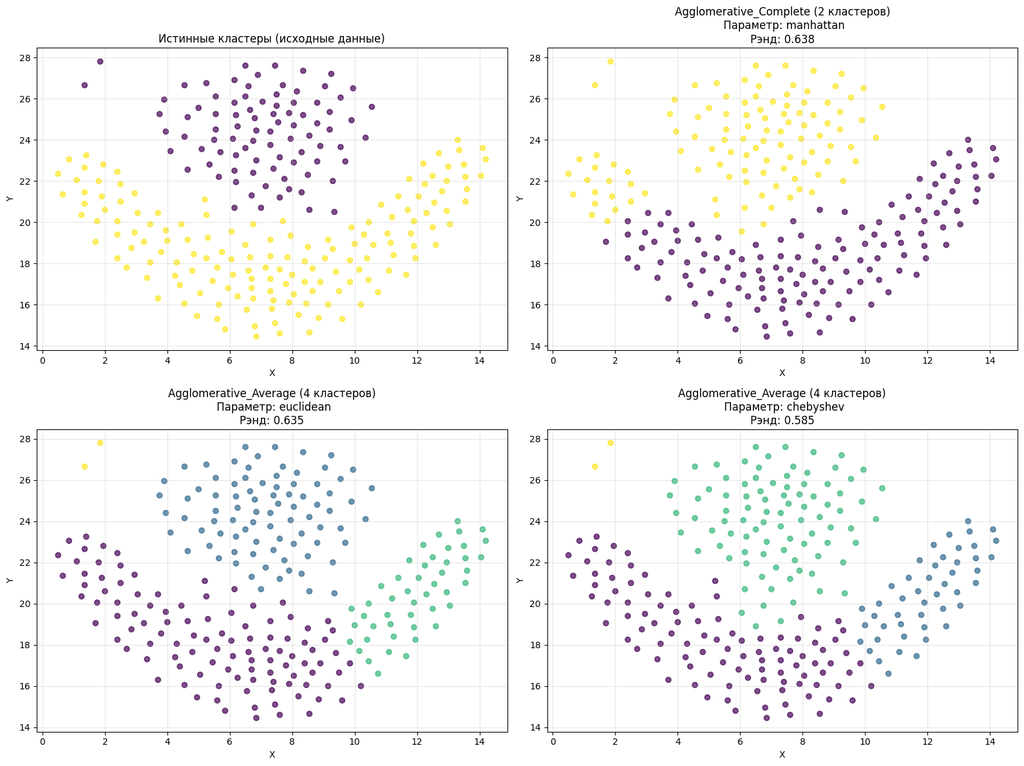

```python
# Подготовка данных для визуализации
fig, axes = plt.subplots(2, 2, figsize=(16, 12))
axes = axes.ravel()

# Исходные данные с истинными метками
axes[0].scatter(flame_data['x'], flame_data['y'], c=true_labels, cmap='viridis', alpha=0.7)
axes[0].set_title('Истинные кластеры (исходные данные)', fontsize=12)
axes[0].set_xlabel('X')
axes[0].set_ylabel('Y')
axes[0].grid(True, alpha=0.3)

# Визуализация топ-3 алгоритмов
for i, (idx, row) in enumerate(top_algorithms_rand.iterrows()):

    # Находим соответствующие метки кластеров
    result = next(r for r in results if r['algorithm'] == row['Алгоритм'] and r['n_clusters'] == row['Кластеры'] and r['other'] == row['Параметр'])
    labels = result['labels']

    axes[i+1].scatter(flame_data['x'], flame_data['y'], c=labels, cmap='viridis', alpha=0.7)
    axes[i+1].set_title(f'{row["Алгоритм"]} ({row["Кластеры"]} кластеров)\n Параметр: {row["Параметр"]}\nРэнд: {row["Индекс Рэнда"]:.3f}', fontsize=12)
    axes[i+1].set_xlabel('X')
    axes[i+1].set_ylabel('Y')
    axes[i+1].grid(True, alpha=0.3)

plt.tight_layout()
plt.show()
```

#### Визуализация результатов лучших алгоритмов по внутренним метриками

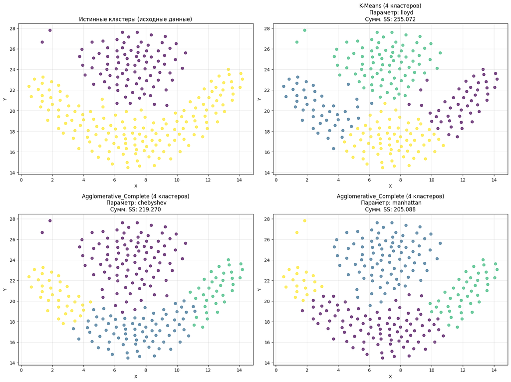

```python
# Подготовка данных для визуализации
fig, axes = plt.subplots(2, 2, figsize=(16, 12))
axes = axes.ravel()

# Исходные данные с истинными метками
axes[0].scatter(flame_data['x'], flame_data['y'], c=true_labels, cmap='viridis', alpha=0.7)
axes[0].set_title('Истинные кластеры (исходные данные)', fontsize=12)
axes[0].set_xlabel('X')
axes[0].set_ylabel('Y')
axes[0].grid(True, alpha=0.3)

# Визуализация топ-3 алгоритмов
for i, (idx, row) in enumerate(top_algorithms_ss.iterrows()):

    # Находим соответствующие метки кластеров
    result = next(r for r in results if r['algorithm'] == row['Алгоритм'] and r['n_clusters'] == row['Кластеры'] and r['other'] == row['Параметр'])
    labels = result['labels']

    axes[i+1].scatter(flame_data['x'], flame_data['y'], c=labels, cmap='viridis', alpha=0.7)
    axes[i+1].set_title(f'{row["Алгоритм"]} ({row["Кластеры"]} кластеров)\n Параметр: {row["Параметр"]}\nCумм. SS: {row["Cумм. SS"]:.3f}', fontsize=12)
    axes[i+1].set_xlabel('X')
    axes[i+1].set_ylabel('Y')
    axes[i+1].grid(True, alpha=0.3)

plt.tight_layout()
plt.show()
```

## Задание 5 (Датасет #2)

### Формулировка

Для прикладного датасета (второй)

- Определить число кластеров
  - методом расчёта сумм расстояний от точек данных до центра ближайшего к ней кластера (инерций).

### Решение

#### Подготовка данных для анализа инерций

```python
# Используем нормализованные данные второго датасета из задания 1
X_seed = seed_data_norm.drop('target', axis=1).values
true_labels_seed = seed_data['target'].values

print("Информация о втором датасете (Seed):")
print(f"Размер данных: {X_seed.shape}")
print(f"Количество истинных классов: {len(np.unique(true_labels_seed))}")
print(f"Распределение по классам: {np.bincount(true_labels_seed)}")
```

```
Информация о втором датасете (Seed):
Размер данных: (210, 7)
Количество истинных классов: 3
Распределение по классам: [70 70 70]
```

#### Вычисление инерций для разного количества кластеров

```python
# Диапазон количества кластеров для тестирования
from pandas import DataFrame

k = 10
k_range = range(1, 1+k)
inertias = []

print(f"\nВычисление инерций для k от 1 до {k}:")
print("-" * 20)

for k in k_range:
    # Выполнение кластеризации K-means
    kmeans = KMeans(n_clusters=k, random_state=42, n_init=10)
    cluster_labels = kmeans.fit_predict(X_seed)

    # Сохранение инерции
    inertias.append(kmeans.inertia_)

DataFrame
display(DataFrame({ 'Шаг': k_range, 'Инерция': inertias }).style.hide(axis='index'))
```

```
Вычисление инерций для k от 1 до 10:
--------------------
```

| Шаг | Инерция |
| --- | --- |
| 1 | 1470.000000 |
| 2 | 659.171754 |
| 3 | 430.658973 |
| 4 | 371.301721 |
| 5 | 326.513695 |
| 6 | 289.804037 |
| 7 | 262.973618 |
| 8 | 240.642603 |
| 9 | 223.034424 |
| 10 | 204.316578 |

#### Построение графика метода "локтя" (Elbow Method)

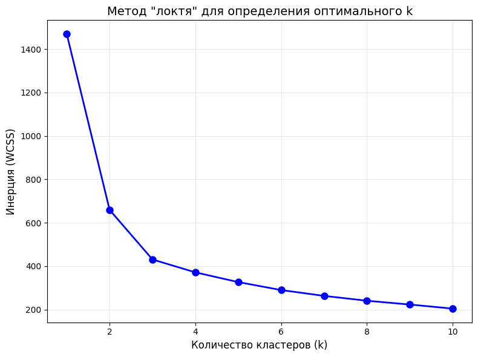

```python
fig, axes = plt.subplots(1, 1, figsize=(8, 6))

# График инерций
axes.plot(k_range, inertias, 'bo-', linewidth=2, markersize=8)
axes.set_title('Метод "локтя" для определения оптимального k', fontsize=14)
axes.set_xlabel('Количество кластеров (k)', fontsize=12)
axes.set_ylabel('Инерция (WCSS)', fontsize=12)
axes.grid(True, alpha=0.3)

plt.tight_layout()
plt.show()
```